# 1. Bike Sharing Data Analysis

Fall 2024 Data Science Project

### Names

Matthew Deik, Abhiram Kidambi, Albert Jeng, Matthew Guo, Rishi Anusuri, Samuel Waters

### Contributions

#### A: Project Idea

- **Matthew Deik**: Proposed the bike-sharing data due to the interesting topic and amount of data available.
- **Rishi Anusuri**: Proposed the question we would answer with our testing

#### B: Dataset Curation and Preprocessing

- **Matthew Deik**: I found dataset 3. I also performed the initial cleaning and data preparation for all datasets.
- **Samuel Waters**: Reformed one of the datasets to be of entries by day instead of hour and aggregated the other columns

#### C: Data Exploration and Summary Statistics

- **Matthew Deik**: Wrote the summary of the statistics for hypothesis 3.
- **Abhiram Kidambi**: Wrote and did the hypothesis tests for hypothesis 1.
- **Samuel Waters**: Wrote and did the hypothesis tests for hypothesis 2, and summarized the statistics.
- **Albert Jeng**: Wrote and did hypothesis tests for hypothesis 3.
- **Matthew Guo**: Plotted preliminary data for hypothesis 1 and provided an analysis.
- **Rishi Anusuri**: Wrote hypothesis 2 and 3

#### D: ML Algorithm Design/Development

- **Abhiram Kidambi**: Wrote and designed the model we chose for Machine Learning and some elementary explanation of why we chose it
- **Samuel Waters**: Implemented the sklearn Machine Learning models we used in order to compare the models.

#### E: ML Algorithm Training and Test Data Analysis

- **Abhiram Kidambi**: Wrote elementary steps to program reg NN and fix some of the errors we were receiving with the model
- **Samuel Waters**: Computed the MSE's and R2 Scores for the sklearn models used

#### F: Visualization, Result Analysis, Conclusion

- **Matthew Guo**: Created plots showing each model's performance. Plotted the graphs in section 6 and wrote the conclusion and provided links to resources.
- **Rishi Anusuri**: determined the conclusion to our testing in final report
- **Albert Jeng**: Interpreted results of all ML models and wrote conclusions

#### G: Final Tutorial Report Creation

- **Matthew Deik**: Created an outline of the report and handled the "Data Curation" section.
- **Rishi Anusuri**: Wrote the introduction to the final report
- **Albert Jeng**: Helped proofread and edit the intoroduction
- **Matthew Guo**: Helped format sections for readability and rewrite the introduction.
- **Abhiram Kidambi**: Helped format to make it seem more like a tutorial

#### H: Additional

- **Matthew Deik**: Helped to coordinate tasks, outline assignments, organize group communication, and ensure tasks were completed on schedule.

## 2. Introduction

We all know biking, and are familiar with it. Some of us in the group also have rented bikes, with Capital bikeshare no less. Running a project on something so local was fascinating to all of us. So the topic we have chosen for this tutorial was determining **how certain factors affect rental bike sales in the Washington D.C. area.**

The question we want to answer from our following analysis is how can Capital Bikeshare as well as other rental bike companies change their rates based on certain factors to boost sales where they may be lacking.

With this tutorial we'll go over the entire data science lifecyle:

1. Data Curation
2. Exploratory Data Analysis
3. Primary Anaylsis
4. Visualization
5. Insights & Conclusions

# 3. Data Curation

#### To find relevant datasets we went to the Capital Bikeshare website and found multiple datasets. We also found helpful data from the UC Irvine site as well.

#### Sources

1. 2011 Capital Bikeshare Data: [capitalbikeshare-data](https://s3.amazonaws.com/capitalbikeshare-data/index.html)
   1. Capital Bikeshare gives information on where the bikes were, where they ended up, and if the person renting the bike was a member or not.
   2. Includes features such as `Duration`, `Start date`, `End date`, `Start station`, `End station`, and `Member type`.
2. 2012 Capital Bikeshare Data: [capitalbikeshare-data](https://s3.amazonaws.com/capitalbikeshare-data/index.html)
   1. Same structure as 2011 data. This was chosen as a continuation to further analyze trends.
   2. Includes features such as `Duration`, `Start date`, `End date`, `Start station`, `End station`, and `Member type`.
3. 2011-2012 Capital Bikeshare Data, w/ Weather Conditions and Seasons: [UC Irvine - Bike Sharing](https://archive.ics.uci.edu/dataset/275/bike+sharing+dataset)
   1. Enhances trip data with external factors that may have impacted the trips of the riders.
   2. Includes features such as `season`, `holiday`, `weekday`, `weathersit`, `temp`, and `windspeed`.

### First

I modified the orginal datasets by combining data from the same year into a single file. The **required datasets** can be found [HERE](https://drive.google.com/file/d/1pR3rJjG2IVe5wnfVTG4lTD_pfvWVhA9V/view?usp=sharing)

### Second

Import required python libraries that will be needed for the datasets and future data analysis.

```python
import pandas as pd
from datetime import datetime
import matplotlib.pyplot as plt
import seaborn as sns
import scipy.stats as stats
import numpy as np
```

### Third

Import the modified datasets into pandas DataFrames.

#### Dataset 1: **2011 Capital Bikeshare Data**

Source: [capitalbikeshare-data](https://s3.amazonaws.com/capitalbikeshare-data/index.html)

```python
b2011_df = pd.read_csv('2011-capitalbikeshare-tripdata.csv')
b2011_df['Start date'] = pd.to_datetime(b2011_df['Start date'])
b2011_df['End date'] = pd.to_datetime(b2011_df['End date'])
b2011_df
```

|  | Duration | Start date | End date | Start station number | Start station | End station number | End station | Bike number | Member type |
| --- | --- | --- | --- | --- | --- | --- | --- | --- | --- |
| 0 | 3548 | 2011-01-01 00:01:29 | 2011-01-01 01:00:37 | 31620 | 5th & F St NW | 31620 | 5th & F St NW | W00247 | Member |
| 1 | 346 | 2011-01-01 00:02:46 | 2011-01-01 00:08:32 | 31105 | 14th & Harvard St NW | 31101 | 14th & V St NW | W00675 | Casual |
| 2 | 562 | 2011-01-01 00:06:13 | 2011-01-01 00:15:36 | 31400 | Georgia & New Hampshire Ave NW | 31104 | Adams Mill & Columbia Rd NW | W00357 | Member |
| 3 | 434 | 2011-01-01 00:09:21 | 2011-01-01 00:16:36 | 31111 | 10th & U St NW | 31503 | Florida Ave & R St NW | W00970 | Member |
| 4 | 233 | 2011-01-01 00:28:26 | 2011-01-01 00:32:19 | 31104 | Adams Mill & Columbia Rd NW | 31106 | Calvert & Biltmore St NW | W00346 | Casual |
| ... | ... | ... | ... | ... | ... | ... | ... | ... | ... |
| 1226762 | 300 | 2011-12-31 23:41:19 | 2011-12-31 23:46:20 | 31201 | 15th & P St NW | 31214 | 17th & Corcoran St NW | W01459 | Member |
| 1226763 | 387 | 2011-12-31 23:46:43 | 2011-12-31 23:53:10 | 31223 | Convention Center / 7th & M St NW | 31201 | 15th & P St NW | W01262 | Member |
| 1226764 | 261 | 2011-12-31 23:47:27 | 2011-12-31 23:51:49 | 31107 | Lamont & Mt Pleasant NW | 31602 | Park Rd & Holmead Pl NW | W00998 | Member |
| 1226765 | 2060 | 2011-12-31 23:55:12 | 2012-01-01 00:29:33 | 31205 | 21st & I St NW | 31222 | New York Ave & 15th St NW | W00042 | Member |
| 1226766 | 468 | 2011-12-31 23:55:56 | 2012-01-01 00:03:45 | 31221 | 18th & M St NW | 31111 | 10th & U St NW | W01319 | Member |

1226767 rows × 9 columns

#### Dataset 2: **2012 Capital Bikeshare Data**

Source: [capitalbikeshare-data](https://s3.amazonaws.com/capitalbikeshare-data/index.html)

```python
b2012_df = pd.read_csv('2012-capitalbikeshare-tripdata.csv')
b2012_df['Start date'] = pd.to_datetime(b2012_df['Start date'])
b2012_df['End date'] = pd.to_datetime(b2012_df['End date'])
b2012_df
```

|  | Duration | Start date | End date | Start station number | Start station | End station number | End station | Bike number | Member type |
| --- | --- | --- | --- | --- | --- | --- | --- | --- | --- |
| 0 | 475 | 2012-01-01 00:04:00 | 2012-01-01 00:11:56 | 31245.0 | 7th & R St NW / Shaw Library | 31109.0 | 7th & T St NW | W01412 | Member |
| 1 | 1162 | 2012-01-01 00:10:05 | 2012-01-01 00:29:28 | 31400.0 | Georgia & New Hampshire Ave NW | 31103.0 | 16th & Harvard St NW | W00524 | Casual |
| 2 | 1145 | 2012-01-01 00:10:23 | 2012-01-01 00:29:28 | 31400.0 | Georgia & New Hampshire Ave NW | 31103.0 | 16th & Harvard St NW | W00235 | Member |
| 3 | 485 | 2012-01-01 00:15:41 | 2012-01-01 00:23:46 | 31101.0 | 14th & V St NW | 31602.0 | Park Rd & Holmead Pl NW | W00864 | Member |
| 4 | 471 | 2012-01-01 00:15:42 | 2012-01-01 00:23:34 | 31102.0 | 11th & Kenyon St NW | 31109.0 | 7th & T St NW | W00995 | Member |
| ... | ... | ... | ... | ... | ... | ... | ... | ... | ... |
| 69621 | 519 | 2012-01-25 08:29:41 | 2012-01-25 08:38:21 | 31229.0 | New Hampshire Ave & T St NW | 31212.0 | 21st & M St NW | W00633 | Member |
| 69622 | 789 | 2012-01-25 08:29:49 | 2012-01-25 08:42:58 | 31614.0 | 11th & H St NE | 31208.0 | M St & New Jersey Ave SE | W00460 | Member |
| 69623 | 748 | 2012-01-25 08:29:50 | 2012-01-25 08:42:18 | 31401.0 | 14th St & Spring Rd NW | 31241.0 | Thomas Circle | W00770 | Member |
| 69624 | 567 | 2012-01-25 08:29:52 | 2012-01-25 08:39:19 | 31602.0 | Park Rd & Holmead Pl NW | 31200.0 | Massachusetts Ave & Dupont Circle NW | W00775 | Member |
| 69625 | 306 | 2012-01-25 08:29:54 | NaT | NaN | NaN | NaN | NaN | NaN | NaN |

69626 rows × 9 columns

#### Dataset 3: **2011-2012 Capital Bikeshare Data, w/ Weather Conditions and Seasons**

Source: [UC Irvine - Bike Sharing](https://archive.ics.uci.edu/dataset/275/bike+sharing+dataset)

```python
bcond_df = pd.read_csv('2011,2012-capitalbikeshare-tripdata+weather+seasonal.csv')
bcond_df['dteday'] = pd.to_datetime(bcond_df['dteday'])
bcond_df
```

|  | instant | dteday | season | yr | mnth | hr | holiday | weekday | workingday | weathersit | temp | atemp | hum | windspeed | casual | registered | cnt |
| --- | --- | --- | --- | --- | --- | --- | --- | --- | --- | --- | --- | --- | --- | --- | --- | --- | --- |
| 0 | 1 | 2011-01-01 | 1 | 0 | 1 | 0 | 0 | 6 | 0 | 1 | 0.24 | 0.2879 | 0.81 | 0.0000 | 3 | 13 | 16 |
| 1 | 2 | 2011-01-01 | 1 | 0 | 1 | 1 | 0 | 6 | 0 | 1 | 0.22 | 0.2727 | 0.80 | 0.0000 | 8 | 32 | 40 |
| 2 | 3 | 2011-01-01 | 1 | 0 | 1 | 2 | 0 | 6 | 0 | 1 | 0.22 | 0.2727 | 0.80 | 0.0000 | 5 | 27 | 32 |
| 3 | 4 | 2011-01-01 | 1 | 0 | 1 | 3 | 0 | 6 | 0 | 1 | 0.24 | 0.2879 | 0.75 | 0.0000 | 3 | 10 | 13 |
| 4 | 5 | 2011-01-01 | 1 | 0 | 1 | 4 | 0 | 6 | 0 | 1 | 0.24 | 0.2879 | 0.75 | 0.0000 | 0 | 1 | 1 |
| ... | ... | ... | ... | ... | ... | ... | ... | ... | ... | ... | ... | ... | ... | ... | ... | ... | ... |
| 17374 | 17375 | 2012-12-31 | 1 | 1 | 12 | 19 | 0 | 1 | 1 | 2 | 0.26 | 0.2576 | 0.60 | 0.1642 | 11 | 108 | 119 |
| 17375 | 17376 | 2012-12-31 | 1 | 1 | 12 | 20 | 0 | 1 | 1 | 2 | 0.26 | 0.2576 | 0.60 | 0.1642 | 8 | 81 | 89 |
| 17376 | 17377 | 2012-12-31 | 1 | 1 | 12 | 21 | 0 | 1 | 1 | 1 | 0.26 | 0.2576 | 0.60 | 0.1642 | 7 | 83 | 90 |
| 17377 | 17378 | 2012-12-31 | 1 | 1 | 12 | 22 | 0 | 1 | 1 | 1 | 0.26 | 0.2727 | 0.56 | 0.1343 | 13 | 48 | 61 |
| 17378 | 17379 | 2012-12-31 | 1 | 1 | 12 | 23 | 0 | 1 | 1 | 1 | 0.26 | 0.2727 | 0.65 | 0.1343 | 12 | 37 | 49 |

17379 rows × 17 columns

## 4. Exploratory Data Analysis

#### Now that we have collected and processed our data, we can begin hypothesis testing to see which features are correlated between each other for further understanding of the dataset.

## Hypothesis 1

HO: The number of bikes rented is distributed uniformly across the top 10 bike stations.

HA: The number of bikes rented is NOT distributed uniformly across the top 10 bike stations.

(For this test, we will just be using the top ten most used starting locations because there are a lot of lesser relevant community metro stations that we don't want to incorporate in this data anlysis.) We use a Chi Squared Goodness of Fit test to check if there is any difference from the uniform distrbiution suggesting some "non-equal" split across the number of bikes rented from the various bike stations.

Plotting rentals by station:

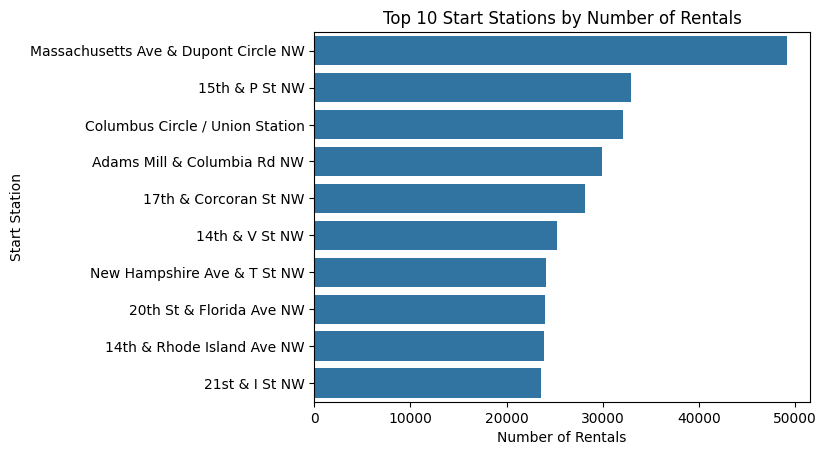

```python
df = b2011_df
sns.countplot(y='Start station', data=b2011_df, order=b2011_df['Start station'].value_counts().index[:10])
plt.title('Top 10 Start Stations by Number of Rentals')
plt.xlabel('Number of Rentals')
plt.ylabel('Start Station')
plt.show()
```

This chart shows that there is some significant differences between the starting location and the number of rentals it has. This overall suggests that the starting station affects the possibility of a bike being rented.

In order to make sure of this, we will use a Chi-Squared Goodness of Fit test which detects whether the difference from a uniform distribution is significant enough to reject the notion that location of where bikes were rented from and the number of rentals are totally independent, or otherwise, follow a uniform distribution.

```python
# top 10 stations and their values
top_10_stations = b2011_df['Start station'].value_counts().nlargest(10)
observed_values = top_10_stations.values

# uniform distro for each stationg iven total values
expected_values = [observed_values.sum() / len(observed_values)] * len(observed_values)

# chi squared test Goodness-of-Fit
chi2_stat, p_value = stats.chisquare(f_obs=observed_values, f_exp=expected_values)

print("Chi-Squared Statistic:", chi2_stat)
print("p-value:", p_value)
```

```
Chi-Squared Statistic: 18730.219752041
p-value: 0.0
```

## Hypothesis 2

HO: The day being a weekend or a weekday does not affect the number of bikes that get rented

HA: The day being a weekend or weekday does affect the number of bikes that get rented

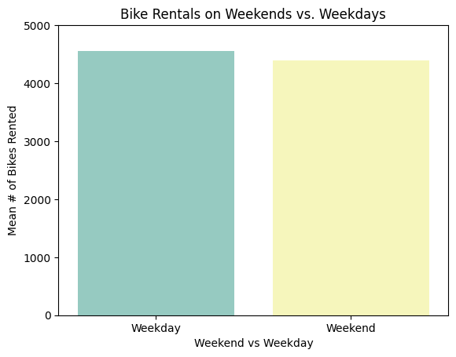

```python
df = bcond_df[['dteday', 'weekday', 'cnt']].groupby(['dteday', 'weekday'], as_index= False).sum()
df['weekend'] = df['weekday'].apply(lambda x: 1 if ((x == 0) or (x == 6)) else 0)
df = df[['weekend', 'cnt']].groupby('weekend', as_index=False).mean()
sns.barplot(df, x='weekend', y='cnt', hue='weekend', palette='Set3',legend=False)
plt.ylim(0, 5000)
plt.xticks(ticks=plt.xticks()[0], labels=['Weekday', 'Weekend'])
plt.xlabel('Weekend vs Weekday')
plt.ylabel('Mean # of Bikes Rented')
plt.title('Bike Rentals on Weekends vs. Weekdays')
plt.show()
```

The chart shows that both weekends and weekdays averages somewhere between 4,000 and 5,000 rentals. It appears that weekdays average a slightly higher number of rentals. Through the use of the T-Statistic, we can evaluate whether the difference in average between these two groups are statistically significant. In doing so, we can determine if the day being a weekend or weekday will affect the number of bikes that get rented.

```python
df = bcond_df[['dteday', 'weekday', 'cnt']].groupby(['dteday', 'weekday'], as_index= False).sum()
df['weekend'] = df['weekday'].apply(lambda x: 1 if ((x == 0) or (x == 6)) else 0)
weekend_group = df[df['weekday'] == 1]['cnt']
weekday_group = df[df['weekday'] == 0]['cnt']

result = stats.ttest_ind(weekend_group, weekday_group)
print('T Statistic: ' + str(result.statistic))
print('P Value: ' + str(result.pvalue))
print('Degrees of Freedom: ' + str(result.df))
```

```
T Statistic: 0.43198371475934083
P Value: 0.6662007194118499
Degrees of Freedom: 208.0
```

Using an alpha level of 0.05:

The p-value resulting from the two sample t-test is larger than the alpha level (0.666 > 0.05)

## Hypothesis 3

HO: The weather does not have an affect on the number of bikes that are rented

HA: The weather has an affect on the number of bikes that are rented

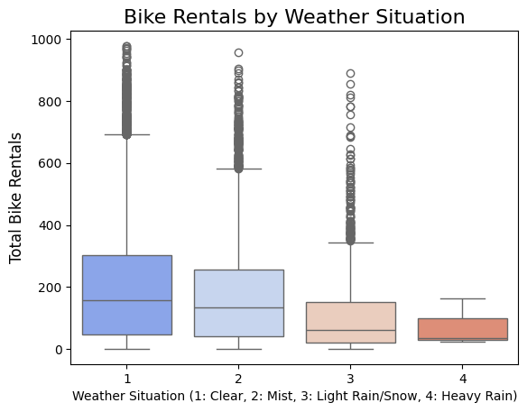

```python
df = bcond_df
sns.boxplot(data=df, x="weathersit", y="cnt", palette="coolwarm")
plt.title("Bike Rentals by Weather Situation", fontsize=16)
plt.xlabel("Weather Situation (1: Clear, 2: Mist, 3: Light Rain/Snow, 4: Heavy Rain)", fontsize=10)
plt.ylabel("Total Bike Rentals", fontsize=12)
plt.show()
```

According to the data illustrated in the boxplot above, total bike rental are highest when the weather is clear. As the weather worsens, the total number of bike rentals decrease. This suggests that there is a relationship between the weather and people's decision to rent a bike. As there are 4 groups of weather conditions presented in the data, we will use ANOVA to test whether the this relationship is significant.

```python
weather_groups = [df[df["weathersit"] == i]["cnt"] for i in df["weathersit"].unique()]
f_stat, p_value = stats.f_oneway(*weather_groups)

print(f_stat)
print(p_value)
```

```
127.17386949967266
1.7347820521803117e-81
```

With a F-value of 127.174, it tells us that there is a huge difference in variance between the groups of weather. And a p-value of essentially 0 tells us that we will reject the null hypothesis. Therefore, weather has a strong correlation on the number of bikes that are rented. F-stat: 127.17386949967266 p-value: 1.7347820521802623e-81

## 5. Primary Analysis

Knowing this information, we desire to create a machine learning model using some type of technique to predict the number of bikes rented on a given day based on various features. There are multiple approaches we can use so we will choose 4 specific models in order to predict the continuous variable that is the number of bike rentals we think will happen on that day. We will test the following models: Linear Regression w/ Polynomial Features, Elastic Net, Bayesian Ridge, and Gradient Boosting Regressor and choose the one that is most accurate.

First we import the required libraries for the models.

```python
from sklearn.model_selection import train_test_split
from sklearn.linear_model import LinearRegression, ElasticNet, BayesianRidge
from sklearn.ensemble import GradientBoostingRegressor
from sklearn.preprocessing import PolynomialFeatures
from sklearn.pipeline import make_pipeline
from sklearn.preprocessing import StandardScaler
from sklearn.metrics import mean_squared_error, r2_score
```

Aggregate data accordingly:

```python
# dataset (w/ weather) sorted by the date.
# temp, atemp, hum, and windspeed are averaged per day
# casual, registered, and cnt are summed per day
# other static information such as season, year, etc. is aggregated with max just to get that single value each day
# the mode of weathersit is taken per day, it could also be averaged instead, but I used mode since the datatype is of discrete categories
bcond_byday_df = bcond_df.groupby('dteday').agg({'season': 'max', 'yr': 'max', 'mnth': 'max', 'holiday': 'max',
                                                 'weekday': 'max', 'workingday': 'max', 'temp': 'mean',
                                                 'atemp': 'mean', 'hum': 'mean', 'windspeed': 'mean',
                                                 'weathersit': lambda x: x.mode()[0], 'casual': 'sum',
                                                 'registered': 'sum', 'cnt': 'sum'}).reset_index()
print(bcond_byday_df)
```

```
        dteday  season  yr  mnth  holiday  weekday  workingday      temp  \
0   2011-01-01       1   0     1        0        6           0  0.344167
1   2011-01-02       1   0     1        0        0           0  0.363478
2   2011-01-03       1   0     1        0        1           1  0.196364
3   2011-01-04       1   0     1        0        2           1  0.200000
4   2011-01-05       1   0     1        0        3           1  0.226957
..         ...     ...  ..   ...      ...      ...         ...       ...
726 2012-12-27       1   1    12        0        4           1  0.254167
727 2012-12-28       1   1    12        0        5           1  0.253333
728 2012-12-29       1   1    12        0        6           0  0.253333
729 2012-12-30       1   1    12        0        0           0  0.255833
730 2012-12-31       1   1    12        0        1           1  0.215833

        atemp       hum  windspeed  weathersit  casual  registered   cnt
0    0.363625  0.805833   0.160446           1     331         654   985
1    0.353739  0.696087   0.248539           2     131         670   801
2    0.189405  0.437273   0.248309           1     120        1229  1349
3    0.212122  0.590435   0.160296           1     108        1454  1562
4    0.229270  0.436957   0.186900           1      82        1518  1600
..        ...       ...        ...         ...     ...         ...   ...
726  0.226642  0.652917   0.350133           2     247        1867  2114
727  0.255046  0.590000   0.155471           2     644        2451  3095
728  0.242400  0.752917   0.124383           2     159        1182  1341
729  0.231700  0.483333   0.350754           1     364        1432  1796
730  0.223487  0.577500   0.154846           1     439        2290  2729

[731 rows x 15 columns]
```

Processing data:

```python
# dropping dteday b/c of issues with converting to float. Adding in a day column since year and month already exist
X = bcond_byday_df.drop(columns=['dteday', 'casual', 'registered', 'cnt'])
X['day'] = bcond_byday_df['dteday'].apply(lambda x: x.day)
y = bcond_byday_df['cnt']

test_size = 0.2

# other degrees were tried and did not result in better predictions
degree = 5

# splitting data
X_train, X_test, y_train, y_test = train_test_split(X, y, test_size=test_size)

scaler = StandardScaler()
```

Creating models:

```python
model_lr = make_pipeline(PolynomialFeatures(degree), LinearRegression())
model_en = ElasticNet()
model_br = BayesianRidge()
model_gbr = GradientBoostingRegressor()

models = {'Linear Regression w/ Polynomial Features': model_lr, 'Elastic Net': model_en,
          'Bayesian Ridge': model_br, 'GradientBoostingRegressor': model_gbr}

for model_name, model in models.items():
  # scaling...
  X_train_scaled = scaler.fit_transform(X_train)
  X_test_scaled = scaler.fit_transform(X_test)

  model.fit(X_train_scaled, y_train)
  y_train_pred = model.predict(X_train_scaled)
  y_test_pred = model.predict(X_test_scaled)

  mse_train = mean_squared_error(y_train, y_train_pred)
  mse_test = mean_squared_error(y_test, y_test_pred)

  r2_train = r2_score(y_train, y_train_pred)
  r2_test = r2_score(y_test, y_test_pred)

  print(model_name, ':')

  print('MSE Train:', mse_train)
  print('MSE Test:', mse_test)

  print('R2 Train:', r2_train)
  print('R2 Test:', r2_test)
```

```
Linear Regression w/ Polynomial Features :
MSE Train: 5.5568704622618185e-21
MSE Test: 5549142.727485939
R2 Train: 1.0
R2 Test: -0.4908161166604539
Elastic Net :
MSE Train: 916997.9547351464
MSE Test: 934515.7654659266
R2 Train: 0.7557152738217093
R2 Test: 0.7489357847061406
Bayesian Ridge :
MSE Train: 726131.2661151892
MSE Test: 726866.1567181471
R2 Train: 0.8065614251411527
R2 Test: 0.8047223085967736
GradientBoostingRegressor :
MSE Train: 145695.96691680173
MSE Test: 337720.8314564162
R2 Train: 0.961187155107852
R2 Test: 0.9092689297802046
```

#### Next we can plot and compare the accuracies between each model.

### Linear Regression w/ Polynomial Features

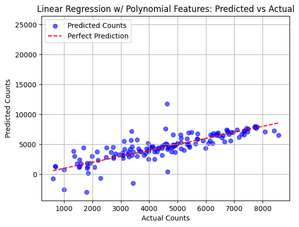

```python
y_test_pred_lr = model_lr.predict(X_test_scaled)

plt.scatter(y_test, y_test_pred_lr, alpha=0.6, label='Predicted Counts', color='blue')
plt.plot([y_test.min(), y_test.max()], [y_test.min(), y_test.max()], color='red', linestyle='--', label='Perfect Prediction')
plt.title('Linear Regression w/ Polynomial Features: Predicted vs Actual')
plt.xlabel('Actual Counts')
plt.ylabel('Predicted Counts')
plt.legend(loc='upper left')
plt.grid(True)
plt.show()
```

### Elastic Net

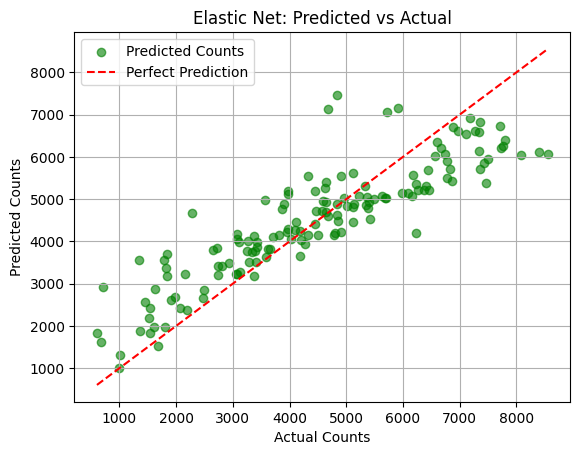

```python
y_test_pred_en = model_en.predict(X_test_scaled)

plt.scatter(y_test, y_test_pred_en, alpha=0.6, label='Predicted Counts', color='green')
plt.plot([y_test.min(), y_test.max()], [y_test.min(), y_test.max()], color='red', linestyle='--', label='Perfect Prediction')
plt.title('Elastic Net: Predicted vs Actual')
plt.xlabel('Actual Counts')
plt.ylabel('Predicted Counts')
plt.legend(loc='upper left')
plt.grid(True)
plt.show()
```

Our Elastic Net model gives us a decent output, with a train $R^2$ of 0.76 and test $R^2$ of 0.74. These similar results tells us that our model performs similarly in the training dataset as well as generalizing on tests. Inherently, as Elastic Net combines L1 and L2 regularization which penalizes large coefficients, it avoids the overfitting issue that we saw in our linear regression model. The MSE is quite high, leaving room for other models to improve on this aspect of better fitting our data.

### Bayesian Ridge

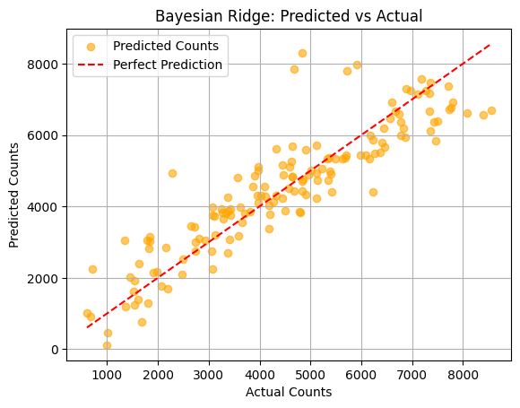

```python
y_test_pred_br = model_br.predict(X_test_scaled)

plt.scatter(y_test, y_test_pred_br, alpha=0.6, label='Predicted Counts', color='orange')
plt.plot([y_test.min(), y_test.max()], [y_test.min(), y_test.max()], color='red', linestyle='--', label='Perfect Prediction')
plt.title('Bayesian Ridge: Predicted vs Actual')
plt.xlabel('Actual Counts')
plt.ylabel('Predicted Counts')
plt.legend(loc='upper left')
plt.grid(True)
plt.show()
```

### Gradient Boosting Regressor

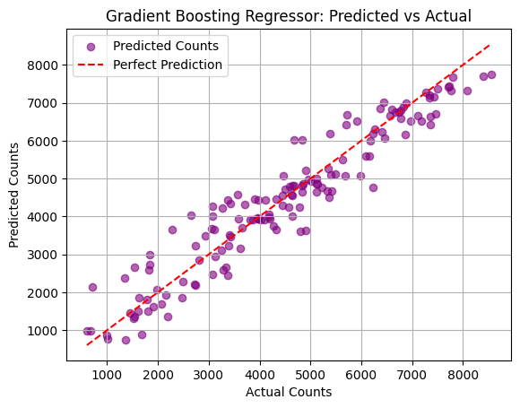

```python
y_test_pred_gbr = model_gbr.predict(X_test_scaled)

plt.scatter(y_test, y_test_pred_gbr, alpha=0.6, label='Predicted Counts', color='purple')
plt.plot([y_test.min(), y_test.max()], [y_test.min(), y_test.max()], color='red', linestyle='--', label='Perfect Prediction')
plt.title('Gradient Boosting Regressor: Predicted vs Actual')
plt.xlabel('Actual Counts')
plt.ylabel('Predicted Counts')
plt.legend(loc='upper left')
plt.grid(True)
plt.show()
```

Our Gradient Boosting Regressor was the best model we had. With a high train $R^2$ value of 0.96 and a high test $R^2$ value of 0.90, we see that this model generalizes quite well. The values are also relatively close to teach other, meaning it performs similarly on known and unknown (generalizing) data. The MSE values are also the lowest (with the exception of linear regression which had extreme overfiting), of the other models, telling us that this Gradient Boosting Regressor model fits our data much better than the Elastic Net and Bayesian Ridge models. Gradient Boosting does well at understanding complex, non-linear relationships like those singificantly present in our data. By building decision trees iteratively and correcting errors on each run, it does well for our non-linear dataset.

# 6. Visualization

#### Given that the Gradient Boosting Regressor model was the most accurate, we'll use it to plot the relationship between predicted rentals and different conditions that showed a correlation from our exploratory data analysis.

## Predicted Rentals vs Weather Conditions

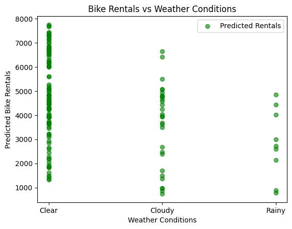

```python
weather_labels = {1: 'Clear', 2: 'Cloudy', 3: 'Rainy'}
weather_conditions = X_test['weathersit'].map(weather_labels)

plt.scatter(weather_conditions, y_test_pred_gbr, alpha=0.6, color='green', label='Predicted Rentals')
plt.title('Bike Rentals vs Weather Conditions')
plt.xlabel('Weather Conditions')
plt.ylabel('Predicted Bike Rentals')
plt.legend(loc='upper right')
plt.show()
```

## Predicted Rentals vs Month

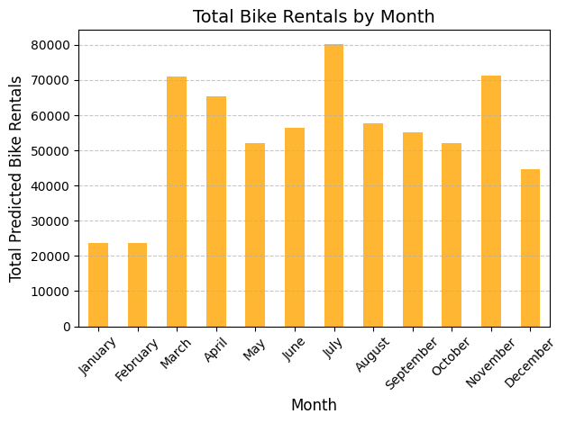

```python
month_labels = {
    1: 'January', 2: 'February', 3: 'March', 4: 'April', 5: 'May', 6: 'June',
    7: 'July', 8: 'August', 9: 'September', 10: 'October', 11: 'November', 12: 'December'
}
X_test['month_name'] = X_test['mnth'].map(month_labels)
monthly_predictions = pd.DataFrame({'Month': X_test['month_name'], 'Predicted Rentals': y_test_pred_gbr})
monthly_totals = monthly_predictions.groupby('Month')['Predicted Rentals'].sum()

monthly_totals = monthly_totals.reindex([
    'January', 'February', 'March', 'April', 'May', 'June',
    'July', 'August', 'September', 'October', 'November', 'December'
])

monthly_totals.plot(kind='bar', color='orange', alpha=0.8)
plt.title('Total Bike Rentals by Month', fontsize=14)
plt.xlabel('Month', fontsize=12)
plt.ylabel('Total Predicted Bike Rentals', fontsize=12)
plt.xticks(rotation=45, fontsize=10)
plt.grid(axis='y', linestyle='--', alpha=0.7)
plt.tight_layout()
plt.show()
```

# 7. Insights and Conclusion

**Based on our throrough analysis and modelling of our datasets we can make the following conclusions:**

1. Bike rentals are highest when the weather is clear. As the weather worsens, the total number of bike rentals decrease.
2. July is the month with the highest bike rentals with November and March following in behind closely. January and February have significantly the lowest # of bike rentals compared to other months.
3. From our hypothesis testing we also found that bike rentals are unproportionately distributed across different stations.

Purely based on these conclusions, bike rental companies can make significant changes to increase sales.

**Here are a few examples**:

1. Increase advertising and offer discounts in January and Febuary to entice riders and overall increase rentals.
2. Offer a rainy day discount when the weather is not clear.

Sources:

- 2011 Capital Bikeshare Data: [capitalbikeshare-data](https://s3.amazonaws.com/capitalbikeshare-data/index.html)
- 2012 Capital Bikeshare Data: [capitalbikeshare-data](https://s3.amazonaws.com/capitalbikeshare-data/index.html)
- 2011-2012 Capital Bikeshare Data, w/ Weather Conditions and Seasons: [UC Irvine - Bike Sharing](https://archive.ics.uci.edu/dataset/275/bike+sharing+dataset)

Resources for further exploration or understanding:

- [Gradient Boosting](https://www.geeksforgeeks.org/ml-gradient-boosting/)
- [Top Machine Learning Methods](https://towardsdatascience.com/10-machine-learning-methods-that-every-data-scientist-should-know-3cc96e0eeee9?gi=4295cd7cf345)
- [Data processing with pandas](https://www.geeksforgeeks.org/data-processing-with-pandas/)
- [Scikit-learn tutorials](https://scikit-learn.org/1.4/tutorial/index.html)
- [Understanding hypothesis testing](https://www.geeksforgeeks.org/understanding-hypothesis-testing/)